# Problema 1 - Checkpoint 1 AD1 UFCG

Diogo Florêncio

```r
library(tidyr)
library(dplyr)
library(ggplot2)
dados <- read.csv("series_from_imdb.csv",encoding="UTF-8")
dados <- dados %>% filter(series_name %in% c("Daredevil", "The Walking Dead", "Prison Break"))
prisonBreak <- dados %>% filter(series_name == "Prison Break")
TWD <- dados %>% filter(series_name == "The Walking Dead")
daredevil <- dados %>% filter(series_name == "Daredevil")
```

# Introdução

### Prison Break

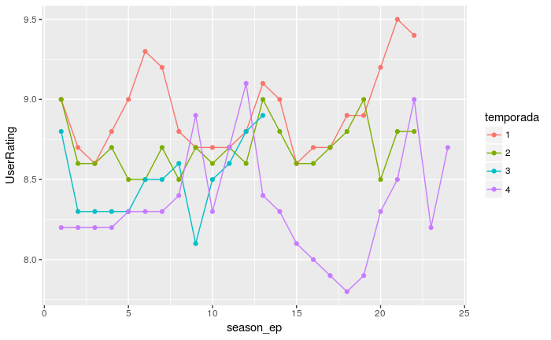

```r
prisonBreak %>%
  mutate(temporada = as.character(season)) %>%
  ggplot(aes(x = season_ep, y = UserRating, color = temporada)) +
  geom_line() +
  geom_point()
```

### The Walking Dead

The Walking Dead é uma série de televisão dramática e pós-apocalíptica norte-americana, estreou no dia 30 outubro de 2010, no canal de televisão a cabo AMC, nos Estados Unidos. A série possui 7 temporadas finalizadas, confira a avaliação dos expectadores para os episódios de cada temporada.

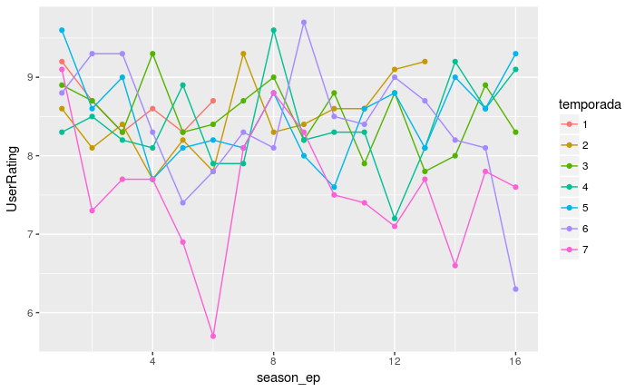

```r
TWD %>%
  mutate(temporada = as.character(season)) %>%
  ggplot(aes(x = season_ep, y = UserRating, color = temporada)) +
  geom_line() +
  geom_point()
```

O 9º episódio “No Way Out”, da 6º temporada se destaca com a maior nota da série com 9,7. A pior avaliação foi atribuida ao 6º episódio “Swear”, da 7º temporada com nota 5,7.

### Daredevil

Daredevil é uma websérie americana criada para a Netflix por Drew Goddard que baseia-se no personagem de mesmo nome da Marvel. Veja a avaliação dos expectadores para os episódios de cada temporada.

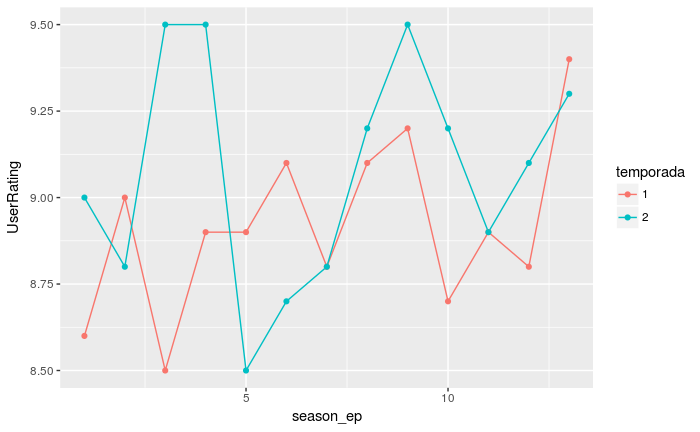

```r
daredevil %>%
  mutate(temporada = as.character(season)) %>%
  ggplot(aes(x = season_ep, y = UserRating, color = temporada)) +
  geom_line() +
  geom_point()
```

Todos os episódios da série estão avaliados entre 8,5 e 9,5. A 2º temporada se destaca com 3 episódios atingindo a maior avaliação, nota 9,5.

# Qual série possui uma avaliação melhor no IMDB?

Considerando a mediana e as notas maximas e mínimas dos episódios de cada série, temos:

```r
dados %>%
    group_by(series_name) %>%
    summarise(mediana = median(UserRating),
              maior_nota = max(UserRating),
              menor_nota = min(UserRating))
```

| series_name | mediana | maior_nota | menor_nota |
| --- | --- | --- | --- |
| Daredevil | 8.95 | 9.5 | 8.5 |
| Prison Break | 8.60 | 9.5 | 7.8 |
| The Walking Dead | 8.30 | 9.7 | 5.7 |

Daredevil possui a melhor avaliação no IMBD. A série apresenta uma mediana superior e se destaca por possuir 3 episódios atingindo a maior avaliação 9,5. Essas caracteristicas garantiram uma pequena vantagem para as demais, em resumo Daredevil proporcionalmente possui uma quantidade maior de episódios melhor avaliados avaliados.

# Qual das séries tem menor regularidade na qualidade dos episódios?

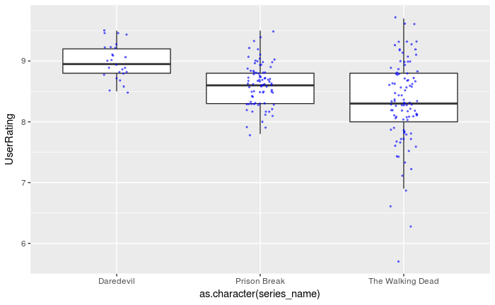

```r
dados %>%
    ggplot(aes(x = as.character(series_name), y = UserRating)) +
    geom_boxplot(outlier.color = NA) +
    geom_jitter(width = .1, size = .5, alpha = .5, color = "blue")
```

Os boxplots das séries, mostram que The Walking Dead possui maior variância na avaliação de seus episódios. Mesmo considerando a avaliação dos epísódios por temporada, ainda sim The Walking Dead possui maior variância. Isto demonstra que a séria não matém uma regularidade na qualidade de seus episódios, sendo bem mais irregular que Daredevi ou Prison Break.

```r
dados %>%
    group_by(series_name, season) %>%
    summarise(variancia = var(UserRating))
```

| series_name | season | variancia |
| --- | --- | --- |
| Daredevil | 1 | 0.06141026 |
| Daredevil | 2 | 0.10692308 |
| Prison Break | 1 | 0.06945887 |
| Prison Break | 2 | 0.02521645 |
| Prison Break | 3 | 0.05666667 |
| Prison Break | 4 | 0.11210145 |
| The Walking Dead | 1 | 0.11066667 |
| The Walking Dead | 2 | 0.24641026 |
| The Walking Dead | 3 | 0.18562500 |
| The Walking Dead | 4 | 0.34000000 |

[output cut: 3 more lines]